# Lab 2: Spatial Analysis and Visualization

## Part 3: Bring Your Own Data Analysis

#### Infrastructure & Services

**Polling Place Accessibility** - **Data:** Polling Places, SEPTA stops, Census tracts (elderly population, disability rates) - **Question:** “Are polling places accessible for elderly and disabled voters?” - **Operations:** Buffer polling places and transit stops, identify vulnerable populations, find areas lacking access - **Policy relevance:** Voting rights, election infrastructure, ADA compliance

1. **Find and load additional data**

```r
# Load your additional dataset
phil_censustract <- st_read("data/Census_Tracts_2010-shp (3)")
polling_places <- st_read("data/polling_places")
transit_stops <- st_read("data/Transit_Stops_(Spring_2025)")

shub <- st_transform(phil_censustract, 3365)
dhub <- st_transform(polling_places,3365)
lhub <- st_transform(transit_stops,3365)
```

**Questions to answer:** - **What dataset did you choose and why?**.

I chose polling places, transit stops and census tracts(for Philadelphia) to analyze voting accessibility.

- **What is the data source and date?**.

The data here are shape files from OpenDataPhilly, all transit Stops as of  
2025, census tracts as of 2010, polling places (no date available)

- **How many features does it contain?**.

  Census Tract (384), Polling Places (1,703), Transit Stops (22,478)
- **What CRS is it in? Did you need to transform it?**.

  I transformed all to 3365 (NAD83)
2. **Pose a research question**.

Do elderly populations have adequate access to polling places via public transit?

3. **Conduct spatial analysis**

```r
# Your spatial analysis


#demographic data from census data using get_acs
a_demographic_data <- get_acs(
  geography = "tract",
  state = "PA",
  county = "PHILADELPHIA",
  variables = c(
    atotal_population = "B01003_001",
    a = "B01001_020",                  #extracting up all 65+ categories
    b = "B01001_021",
    c = "B01001_022",
    d = "B01001_023",
    e = "B01001_024",
    f = "B01001_025",
    g = "B01001_044",
    h = "B01001_045",
    i = "B01001_046",
    j = "B01001_047",
    k = "B01001_048",
    l = "B01001_049"
  ),
  year = 2022,
  survey = "acs5",
  output = "wide"
) %>%                                  #calculating the total population 65+
  mutate(
    apop_65plusE = aE + bE + cE + dE + eE + fE + gE + hE + iE + jE + kE + lE
  ) %>%
  mutate(                              #cleaning (removing) strings that were unnecessary
    NAME = NAME %>%
      str_remove("Census Tract ") %>%
      str_remove("; Pennsylvania")
  ) %>%
  select(                               #rename relevant columns for analysis
    GEOID,
    `County Name` = NAME,
    `Total Population` = atotal_populationE,
    `Total Population 65 Y+` = apop_65plusE
  )


# joining demographic data to census tracts in Philadelphia
a_census_tract_join <- shub %>%
  left_join(a_demographic_data, by = c("GEOID10" = "GEOID"))


# identifying vulnerable tracts 1/3 mile distance from centroid to polling places
a_vulnerable_tracts <- a_census_tract_join %>%
  mutate(
    percent = (`Total Population 65 Y+` / `Total Population`) * 100,
    a_distance = as.numeric(st_distance(st_centroid(shub), st_union(dhub))),
    vulnerability = case_when(
      percent > 40 & a_distance > 600 ~ "Vulnerable!",
      TRUE ~ "Not Vulnerable"
    )
  )



# filter to vulnerable tracts
identify_vulnerabilitya <- a_vulnerable_tracts %>%
  filter(vulnerability == "Vulnerable!")


# creating buffer of 0.125 mile around transit stops (easy access for senior citizes)
stop_buffer <- lhub %>%
  st_buffer(200)


#identifying critical tracts (using disjoint to exclude areas not covered by the transit buffer)
critical_tracts <- identify_vulnerabilitya %>%
  st_filter(stop_buffer, .predicate = st_disjoint)


#Identifying most priritizable among the critical tracts, prioritizing based on distance to polling place, followed by percent of 65+
top_critical_tracts <- critical_tracts %>%
  st_drop_geometry() %>%
  arrange(desc(a_distance), desc(percent)) %>%
  mutate(
    `Tract` = str_remove(NAMELSAD10, "Census Tract "),
    `Total Population` = comma(`Total Population`),
    `Avg Distance to Polling Places (mi)` = a_distance / 1609.34
  ) %>%
  select(
    `Tract`,
    `Total Population`,
    `% Vulnerable` = percent,
    `Avg Distance to Polling Places (mi)`
  )


#viewing and labeling
top_critical_tracts %>%
  kable(
    digits = 1,
    caption = "Critical Tracts for Investment in Elderly Participation in Elections"
  )
```

Critical Tracts for Investment in Elderly Participation in Elections

| Tract | Total Population | % Vulnerable | Avg Distance to Polling Places (mi) |
| --- | --- | --- | --- |
| 364 | 1,004 | 49.8 | 1.9 |
| 220 | 1,477 | 46.6 | 1.9 |
| 9802 | 405 | 76.5 | 0.8 |

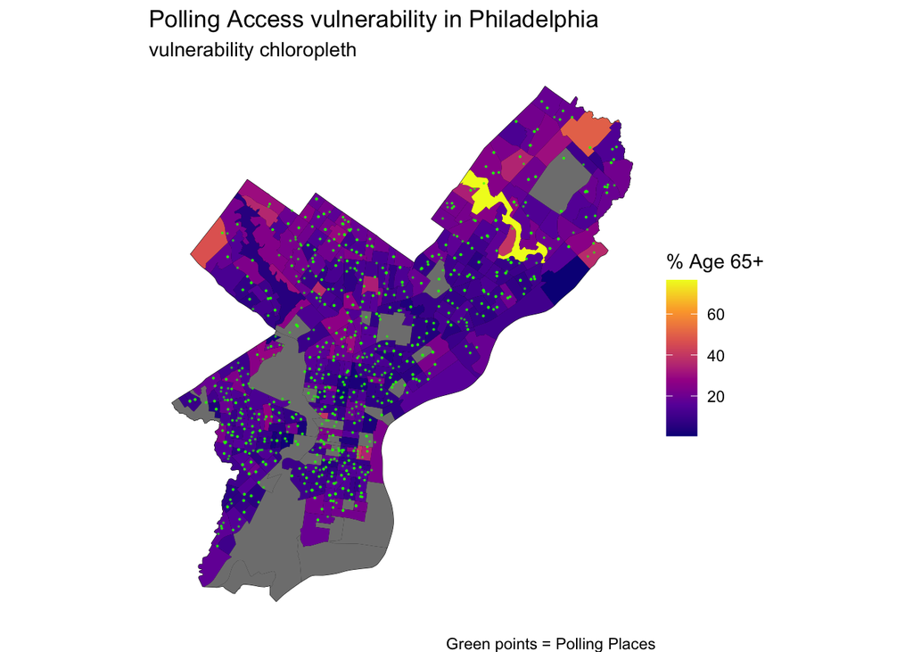

```r
#mapping vulnerable tracts and hospitals for visual understanding
ggplot() +
  geom_sf(data = shub, fill = "white", color = "black") +
  geom_sf(data = a_vulnerable_tracts, aes(fill = percent), color = NA) +
  geom_sf(data = dhub, color = "green", size = 0.05, alpha = 0.5) +
  scale_fill_viridis_c(name = "% Age 65+", option = "plasma") +
  labs(
    title = "Polling Access vulnerability in Philadelphia",
    subtitle = "vulnerability chloropleth",
    caption = "Green points = Polling Places"
  ) +
  theme_void()
```

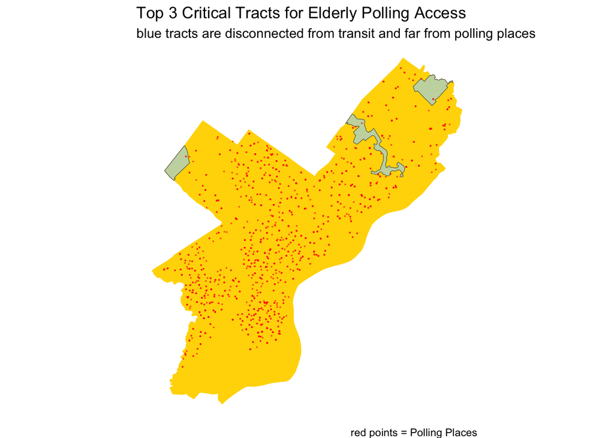

```r
#converting critical tracts into geometric
critical_top3pls <- critical_tracts %>%
  filter(NAMELSAD10 %in% c("Census Tract 364", "Census Tract 220", "Census Tract 9802"))



ggplot() +
  geom_sf(data = shub, fill = "gold", color = "gold") +
  geom_sf(data = critical_top3pls, fill = "lightblue", alpha = 0.7) +
  geom_sf(data = dhub, color = "red", size = 0.05, alpha = 0.5) +
  labs(
    title = "Top 3 Critical Tracts for Elderly Polling Access",
    subtitle = "blue tracts are disconnected from transit and far from polling places",
    caption = "red points = Polling Places"
  ) +
  theme_void()
```

## Comments about your incorporation of feedback!

I cleaned up the presentation and only included essential information for display on quarto. Unnecessary details were attempted to be excluded. I formatted only tabels that were asked to display

## Acknowledgements

I consulted lab1 codes, week4 lecture codes, week4 inclass practice codes,week 3 lab exercies, week 3 qmd.

I also consulted:

sf cheat sheet:

https://rstudio.github.io/cheatsheets/sf.pdf.

gg plot cheat sheet:

https://rstudio.github.io/cheatsheets/data-visualization.pdf.

dplyr cheat sheet: https://nyu-cdsc.github.io/learningr/assets/data-transformation.pdf.

Besides I consulted Claude and Chat GPT- coding by myself, then consulting it for corrections.